# Craft Beer Market Analysis

Team Members: Linda Eliasen and Limin Zheng

February 2019

Github: *https://github.com/laelias7/DDS---Project-1.git*

YouTube - Linda: *https://youtu.be/l6h0L66IF8o*

### Our team used the data provided by the company for the analysis. We were also able to obtain additional industry key metrics from The Brewers Association, an American trade group of over 7,200 brewers, which was incorporated into the analysis to provide more depth.

```r
brew<- read.csv("breweries.csv" , header=TRUE, stringsAsFactors=FALSE)
  colnames(brew)<- c('Brewery_id', 'Name', 'City', 'State')

beer <- read.csv("beers.csv" , header=TRUE, stringsAsFactors=FALSE)

brew<-merge(brew,beer, by="Brewery_id",all.x = TRUE)
colnames(brew)<- c('Brewery_id', 'Brewery', 'City', 'State', 'Beer', 'Beer_ID', 'ABV', 'IBU', 'Style', 'Ounces')
brew$IBU <- as.numeric(brew$IBU)

sbystate <- read.csv("StateStats.csv" , header=TRUE, stringsAsFactors=FALSE)
sbystate$Economic.Impact.Mil<-as.numeric(sbystate$Economic.Impact.Mil)
sbystate$Economic.Impact.Rank<-as.numeric(sbystate$Economic.Impact.Rank)
sbystate$Barrels.Per.Year<-as.numeric(sbystate$Barrels.Per.Year)
```

#### Below is a quick snapshot (top and bottom) of the data included in the files provided by the company

```r
brew <- brew %>%
    select(Brewery, Beer, Style, ABV, IBU, Ounces, City, State, Beer_ID, Brewery_id)

kable(head(brew,6))%>%
  kable_styling(full_width = F)
```

| Brewery | Beer | Style | ABV | IBU | Ounces | City | State | Beer_ID | Brewery_id |
| --- | --- | --- | --- | --- | --- | --- | --- | --- | --- |
| NorthGate Brewing | Pumpion | Pumpkin Ale | 0.060 | 38 | 16 | Minneapolis | MN | 2689 | 1 |
| NorthGate Brewing | Stronghold | American Porter | 0.060 | 25 | 16 | Minneapolis | MN | 2688 | 1 |
| NorthGate Brewing | Parapet ESB | Extra Special / Strong Bitter (ESB) | 0.056 | 47 | 16 | Minneapolis | MN | 2687 | 1 |
| NorthGate Brewing | Get Together | American IPA | 0.045 | 50 | 16 | Minneapolis | MN | 2692 | 1 |
| NorthGate Brewing | Maggie’s Leap | Milk / Sweet Stout | 0.049 | 26 | 16 | Minneapolis | MN | 2691 | 1 |
| NorthGate Brewing | Wall’s End | English Brown Ale | 0.048 | 19 | 16 | Minneapolis | MN | 2690 | 1 |

```r
kable(tail(brew,6))%>%
  kable_styling(full_width = F)
```

|  | Brewery | Beer | Style | ABV | IBU | Ounces | City | State | Beer_ID | Brewery_id |
| --- | --- | --- | --- | --- | --- | --- | --- | --- | --- | --- |
| 2405 | Ukiah Brewing Company | Pilsner Ukiah | German Pilsener | 0.055 | NA | 12 | Ukiah | CA | 98 | 556 |
| 2406 | Butternuts Beer and Ale | Porkslap Pale Ale | American Pale Ale (APA) | 0.043 | NA | 12 | Garrattsville | NY | 49 | 557 |
| 2407 | Butternuts Beer and Ale | Snapperhead IPA | American IPA | 0.068 | NA | 12 | Garrattsville | NY | 51 | 557 |
| 2408 | Butternuts Beer and Ale | Moo Thunder Stout | Milk / Sweet Stout | 0.049 | NA | 12 | Garrattsville | NY | 50 | 557 |
| 2409 | Butternuts Beer and Ale | Heinnieweisse Weissebier | Hefeweizen | 0.049 | NA | 12 | Garrattsville | NY | 52 | 557 |
| 2410 | Sleeping Lady Brewing Company | Urban Wilderness Pale Ale | English Pale Ale | 0.049 | NA | 12 | Anchorage | AK | 30 | 558 |

##### There are 1005 beers in the data without an IBU rating, and 62 Beers without ABV information. We are leaving these rows in the data set so we can keep the other key data points for these beers.

```r
sha<-colSums(is.na(brew))
kable(sha)%>%
  kable_styling(full_width = F)
```

|  | x |
| --- | --- |
| Brewery | 0 |
| Beer | 0 |
| Style | 0 |
| ABV | 62 |
| IBU | 1005 |
| Ounces | 0 |
| City | 0 |
| State | 0 |
| Beer_ID | 0 |
| Brewery_id | 0 |

### CRAFT BEER DEMOGRAPHICS BY STATE

##### Below is the combined summary of the data, including the additional metrics from The Brewers Association. That additional data points at the state level include: Breweries Per Capita, Economic $ Impact, Economic Impact Rank, Barrels Produced Annually and Gallons Produced Per Adult.

```r
state <-as.data.frame(brew%>% group_by(State)
  %>% summarise(MedianABV=median(ABV, na.rm=TRUE),
  MedianIBU=median(IBU, na.rm=TRUE),
  Breweries = n_distinct(Brewery_id)))

state$Breweries<- as.numeric(state$Breweries)

state<-merge(state, sbystate, by="State",all.x = TRUE)
colnames(state)<- c('State', 'MedianABV', 'MedianIBU', 'Breweries','BreweriesPerCapita', 'EconomicImpactM$', 'EconomicImpactRank', 'BarrelsPerYear', 'GallonsPerAdult')

kable(state)%>%
kable_styling(bootstrap_options = "striped", "condensed")
```

| State | MedianABV | MedianIBU | Breweries | BreweriesPerCapita | EconomicImpactM$ | EconomicImpactRank | BarrelsPerYear | GallonsPerAdult |
| --- | --- | --- | --- | --- | --- | --- | --- | --- |
| AK | 0.0560 | 46.0 | 7 | 6.8 | 232 | 45 | 204302 | 12.0 |
| AL | 0.0600 | 43.0 | 3 | 0.9 | 616 | 29 | 62738 | 0.5 |
| AR | 0.0520 | 39.0 | 2 | 1.6 | 406 | 37 | 42294 | 0.6 |
| AZ | 0.0550 | 20.5 | 11 | 1.9 | 1000 | 22 | 147728 | 0.9 |
| CA | 0.0580 | 42.0 | 39 | 2.6 | 7345 | 1 | 3285525 | 3.5 |
| CO | 0.0605 | 40.0 | 47 | 8.4 | 3037 | 6 | 1523204 | 11.4 |
| CT | 0.0600 | 29.0 | 8 | 2.2 | 718 | 26 | 166848 | 1.9 |
| DC | 0.0625 | 47.5 | 1 | 2.2 | 235 | 47 | 33025 | 1.9 |
| DE | 0.0550 | 52.0 | 2 | 2.9 | 318 | 41 | 292741 | 12.6 |
| FL | 0.0570 | 55.0 | 15 | 1.5 | 3074 | 5 | 1408032 | 2.7 |
| GA | 0.0550 | 55.0 | 7 | 0.9 | 1596 | 17 | 408798 | 1.7 |
| HI | 0.0540 | 22.5 | 4 | 1.7 | 245 | 46 | 69561 | 2.0 |
| IA | 0.0555 | 26.0 | 5 | 3.3 | 861 | 23 | 78946 | 1.1 |
| ID | 0.0565 | 39.0 | 5 | 4.5 | 366 | 38 | 90318 | 2.3 |
| IL | 0.0580 | 30.0 | 18 | 2.1 | 2602 | 8 | 385874 | 1.3 |
| IN | 0.0580 | 33.0 | 22 | 2.8 | 1309 | 19 | 240063 | 1.5 |
| KS | 0.0500 | 20.0 | 3 | 1.7 | 480 | 31 | 46725 | 0.7 |
| KY | 0.0625 | 31.5 | 4 | 1.6 | 657 | 27 | 125302 | 1.2 |
| LA | 0.0520 | 31.5 | 5 | 1.0 | 740 | 25 | 215168 | 2.0 |
| MA | 0.0540 | 35.0 | 23 | 2.5 | 1838 | 14 | 584895 | 3.5 |
| MD | 0.0580 | 29.0 | 7 | 1.6 | 826 | 24 | 293298 | 2.0 |
| ME | 0.0510 | 61.0 | 9 | 9.6 | 476 | 32 | 319590 | 9.6 |
| MI | 0.0620 | 35.0 | 32 | 4.5 | 2094 | 9 | 873995 | 3.7 |
| MN | 0.0560 | 44.5 | 12 | 3.9 | 2007 | 12 | 650974 | 5.0 |
| MO | 0.0520 | 24.0 | 9 | 2.0 | 1047 | 21 | 372840 | 2.6 |
| MS | 0.0580 | 45.0 | 2 | 0.6 | 310 | 42 | 30254 | 0.4 |
| MT | 0.0550 | 40.0 | 9 | 9.6 | 417 | 35 | 188449 | 7.5 |
| NC | 0.0570 | 33.5 | 19 | 3.4 | 2042 | 10 | 1211393 | 5.0 |
| ND | 0.0500 | 32.0 | 1 | 2.2 | 200 | 49 | 12848 | 0.7 |
| NE | 0.0560 | 35.0 | 5 | 3.6 | 465 | 33 | 53655 | 1.2 |
| NH | 0.0550 | 48.5 | 3 | 5.6 | 353 | 39 | 103329 | 3.1 |
| NJ | 0.0460 | 34.5 | 3 | 1.3 | 1636 | 16 | 139562 | 0.6 |
| NM | 0.0620 | 51.0 | 4 | 4.4 | 333 | 40 | 116023 | 2.4 |
| NV | 0.0600 | 41.0 | 2 | 1.8 | 434 | 34 | 64621 | 0.9 |
| NY | 0.0550 | 47.0 | 16 | 2.2 | 3439 | 4 | 1211494 | 2.5 |
| OH | 0.0580 | 40.0 | 15 | 2.6 | 2675 | 7 | 1355279 | 4.9 |
| OK | 0.0600 | 35.0 | 6 | 1.0 | 502 | 30 | 52807 | 0.6 |
| OR | 0.0560 | 40.0 | 29 | 8.5 | 1988 | 13 | 1078391 | 10.7 |
| PA | 0.0570 | 30.0 | 25 | 2.9 | 5788 | 2 | 3724010 | 12.0 |
| RI | 0.0550 | 24.0 | 5 | 2.1 | 152 | 51 | 26295 | 1.0 |
| SC | 0.0550 | 30.0 | 4 | 1.6 | 650 | 28 | 108211 | 0.9 |
| SD | 0.0600 | NA | 1 | 2.6 | 209 | 48 | 14057 | 0.7 |
| TN | 0.0570 | 37.0 | 3 | 1.7 | 1135 | 20 | 253782 | 1.6 |
| TX | 0.0550 | 33.0 | 28 | 1.3 | 4540 | 3 | 1156536 | 1.8 |
| UT | 0.0400 | 34.0 | 4 | 1.5 | 415 | 36 | 206529 | 3.1 |
| VA | 0.0565 | 42.0 | 16 | 3.0 | 1373 | 18 | 358903 | 1.8 |
| VT | 0.0550 | 30.0 | 10 | 11.5 | 309 | 43 | 292479 | 18.9 |
| WA | 0.0555 | 38.0 | 23 | 6.7 | 1770 | 15 | 510682 | 2.9 |
| WI | 0.0520 | 19.0 | 20 | 3.7 | 2015 | 11 | 1029916 | 7.5 |
| WV | 0.0620 | 57.5 | 1 | 1.7 | 293 | 44 | 12989 | 0.3 |
| WY | 0.0500 | 21.0 | 4 | 5.7 | 177 | 50 | 45401 | 3.3 |

##### Below is a heat map based on total breweries by state. The top five states with the most breweries are: Colorado (47), California (39), Michigan (32), Oregon (29) and Texas (28).

```r
mapdata <- get_data_from_map(download_map_data("countries/us/us-all"))

#need to remove extra spaces from state abreviation
state$State <- str_trim(state$State,side="left")
state <- state %>% mutate(`hc-a2`= State);

hcmap("countries/us/us-all", data = state, value = "Breweries",
      joinBy = "hc-a2", name = "Breweries",
      dataLabels = list(enabled = TRUE, format = '{point.name}'),
      borderColor = "#FAFAFA", borderWidth = 0.1,
      tooltip = list(valueDecimals = 0,valueSuffix = " Breweries")) %>%
    hc_mapNavigation(enabled = TRUE) %>%
    hc_title(text = "<b>Number of Breweries by State</b>",
             margin = 20, align = "center",
             style = list(color = "#000000",
                         useHTML = TRUE))
```

[interactive chart not shown]

##### As each state’s population of drinking age adults plays a role in understanding brewery counts, the below map is reflective of breweries per capita (per 100,000 21+ adults). When looking at the data based on this metric, we see a notable shift in state rankings. Vermont (11.5), Maine (9.6), Montanna (9.6), Oregon (8.5) and Colorado (8.4) now hold the top five spots.

```r
mapdata <- get_data_from_map(download_map_data("countries/us/us-all"))

#need to remove extra spaces from state abreviation
state$State <- str_trim(state$State,side="left")
state <- state %>% mutate(`hc-a2`= State);

hcmap("countries/us/us-all", data = state, value = "BreweriesPerCapita",
      joinBy = "hc-a2", name = "BreweriesPerCapita",
      dataLabels = list(enabled = TRUE, format = '{point.name}'),
      borderColor = "#FAFAFA", borderWidth = 0.1,
      tooltip = list(valueDecimals = 0,valueSuffix = " Breweries")) %>%
    hc_mapNavigation(enabled = TRUE) %>%
    hc_title(text = "<b>Breweries Per Capita<b>",
                 margin = 20, align = "center",
             style = list(color = "#000000",
                         useHTML = TRUE))
```

[interactive chart not shown]

Combined bar chart to compare Median ABV and IBU by State

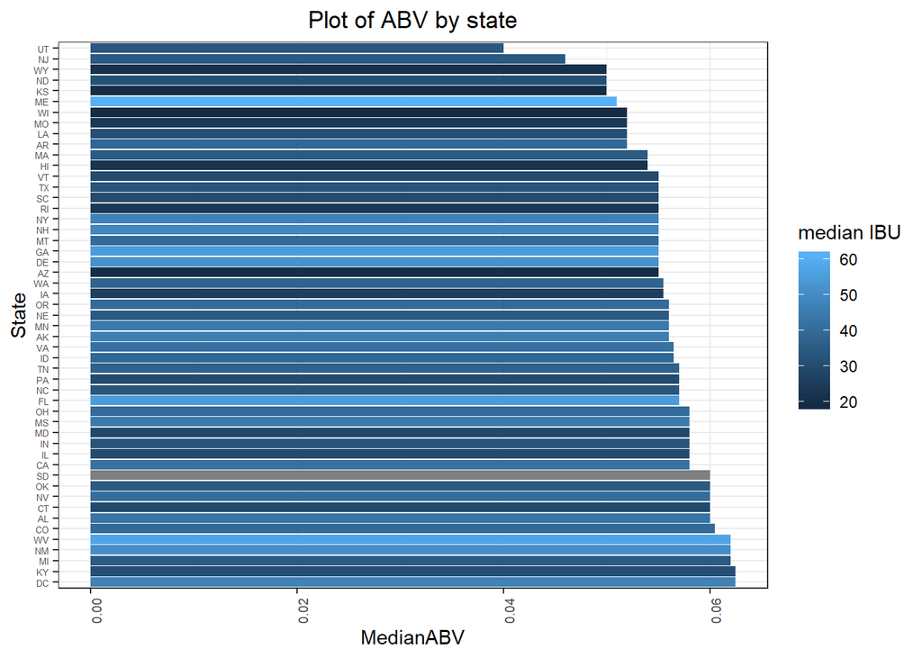

```r
ggplot(state, aes(x=reorder(State, -MedianABV),y=MedianABV, fill=MedianIBU))+labs(title="Plot of ABV by state", x="State", y="MedianABV", fill="median IBU")+geom_bar(stat="identity") + theme_bw() +theme(axis.text.x=element_text(angle=90, size = 7)) +theme(plot.title = element_text(hjust = 0.5))+theme(axis.text.y = element_text(hjust=1, vjust=0.5, size=5))+coord_flip()
```

##### Like ABV, IBU (International Bitterness Units) is another common measurement for beer. The various graphs below show the median ABV and IBU by state. If we look at median ABV by state, we see that there are not vast differences, with the expected exception of Utah. Median IBU is another story, there are clear differences by state when it comes to the preferred bitterness.

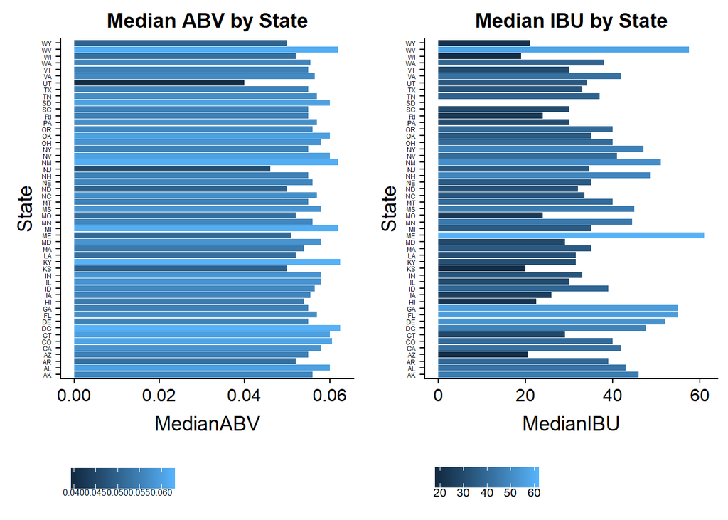

```r
#Graph side by side
abv<-ggplot(state, aes(x=State, y=MedianABV, fill=MedianABV)) +
  geom_bar(stat="identity") +
  ggtitle("Median ABV by State") +
  theme(plot.title = element_text(hjust = 0.5))+
  theme(axis.text.y = element_text(hjust=1, vjust=0.5, size=4.5))+
  theme(legend.position="bottom")+
  theme(legend.text = element_text(colour="black", size =6))+
  theme(legend.title = element_blank()) +
  coord_flip()

ibu<-ggplot(state, aes(x=State, y=MedianIBU, fill=MedianIBU)) +
  geom_bar(stat="identity") +
  ggtitle("Median IBU by State") +
  theme(plot.title = element_text(hjust = 0.5))+
  theme(axis.text.y = element_text(hjust=1, vjust=0.5, size=4.5))+
  theme(legend.position="bottom")+
  theme(legend.text = element_text(colour="black", size =8))+
  theme(legend.title = element_blank()) +
  coord_flip()

plotf<-plot_grid(abv, ibu, align="hv", nrow = 1, ncol = 2)

plotf
```

##### Colorado’s Lee Hill Series Vol. 5 has the highest ABV at 0.128 and Oregon’s Bitter Bitch Imperial IPA has the most bitter beer at an IBU rating of 138.

```r
ma <- data.frame(brew[order(-brew$ABV),])
ma=ma[1,c(8,2,4,5)]
ma<-ma[1, ]
mi <- data.frame(brew[order(-brew$IBU),])
mi=mi[1,c(8,2,4,5)]
mi<-mi[1, ]

top<-rbind(ma, mi)
top[is.na(top)] <- ""

kable(head(top[,1:4]),
      format = "pandoc",
      digits = 3,
      caption = "State with Highest ABV and Most Bitter Beer",
      col.names = c("State","Beer","ABV","IBU"),
      row.names = FALSE,
      align = c("l"))
```

State with Highest ABV and Most Bitter Beer

| State | Beer | ABV | IBU |
| --- | --- | --- | --- |
| CO | Lee Hill Series Vol. 5 - Belgian Style Quadrupel Ale | 0.128 |  |
| OR | Bitter Bitch Imperial IPA | 0.082 | 138 |

##### Summary statistics for Alcohol by Volume and International Bitterness Units

```r
Alcohol_by_Volume<-(summary(brew$ABV, na.rm=TRUE, digits=3 ))

International_Bitterness_Units<-(summary(brew$IBU, na.rm=TRUE))

abv<-rbind(Alcohol_by_Volume)
kable(abv)%>%
 kable_styling(full_width = F)
```

|  | Min. | 1st Qu. | Median | Mean | 3rd Qu. | Max. | NA’s |
| --- | --- | --- | --- | --- | --- | --- | --- |
| Alcohol_by_Volume | 0.001 | 0.05 | 0.056 | 0.0598 | 0.067 | 0.128 | 62 |

```r
ibu<-rbind(International_Bitterness_Units)
kable(ibu)%>%
  kable_styling(full_width = F)
```

|  | Min. | 1st Qu. | Median | Mean | 3rd Qu. | Max. | NA’s |
| --- | --- | --- | --- | --- | --- | --- | --- |
| International_Bitterness_Units | 4 | 21 | 35 | 42.71317 | 64 | 138 | 1005 |

##### The frequency distributions of ABV and IBU show some interesting patterns. The histogram of alcohol by volume is a right skewed distribution and indicates that consumers prefer beers with alcohol content below the mean of .06.

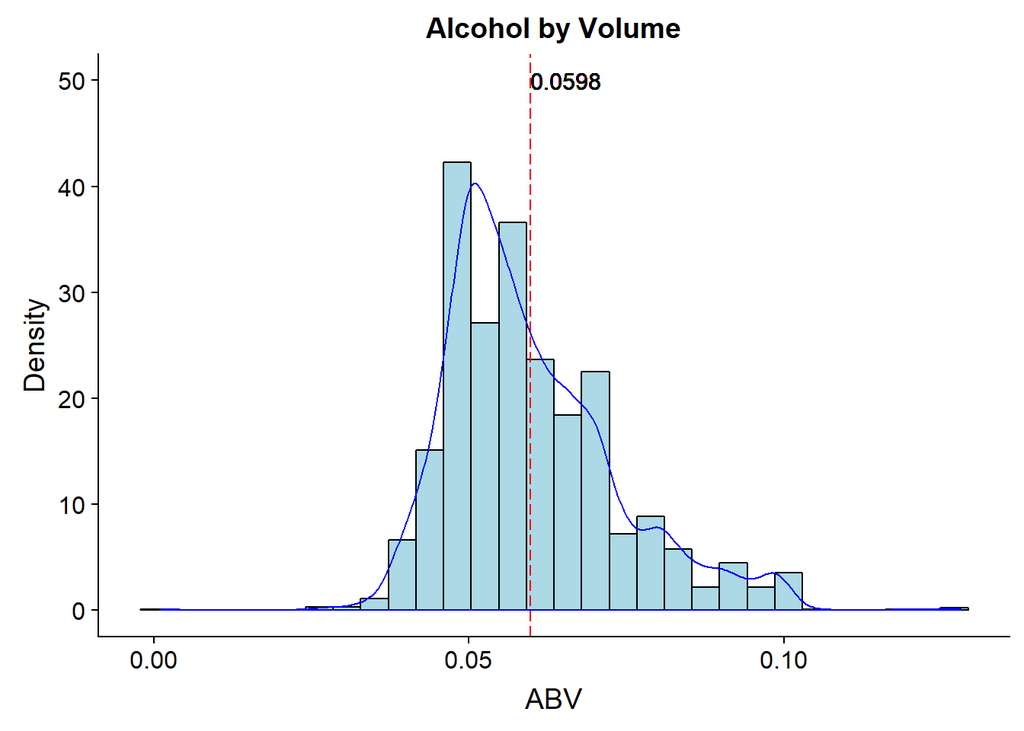

```r
ggplot(brew, aes(x=ABV)) +
 geom_histogram(aes(y=..density..), colour="black", fill="lightblue",
                position="identity")+
    geom_density(alpha=.2, color="blue")+
    geom_vline(aes(xintercept=mean(brew$ABV, na.rm = T)), color="red",
             linetype="longdash")+
    labs(title="Alcohol by Volume",x="ABV", y = "Density")+
    geom_text(data=brew, mapping=aes(x=mean(brew$ABV, na.rm = T), y=50, label=round(mean(brew$ABV, na.rm = T),digits=4)), size=4, hjust=-0)
```

##### International Bitterness Units is a bi-modal (or double peaked) distribution and we can see two distinct preferences: We see a larger group that prefers beers that have an IBU below the mean of 43, and a secondary group that prefer a beer that is more bitter. For this group we see a concentration range between roughly 60 and 75 IBUs.

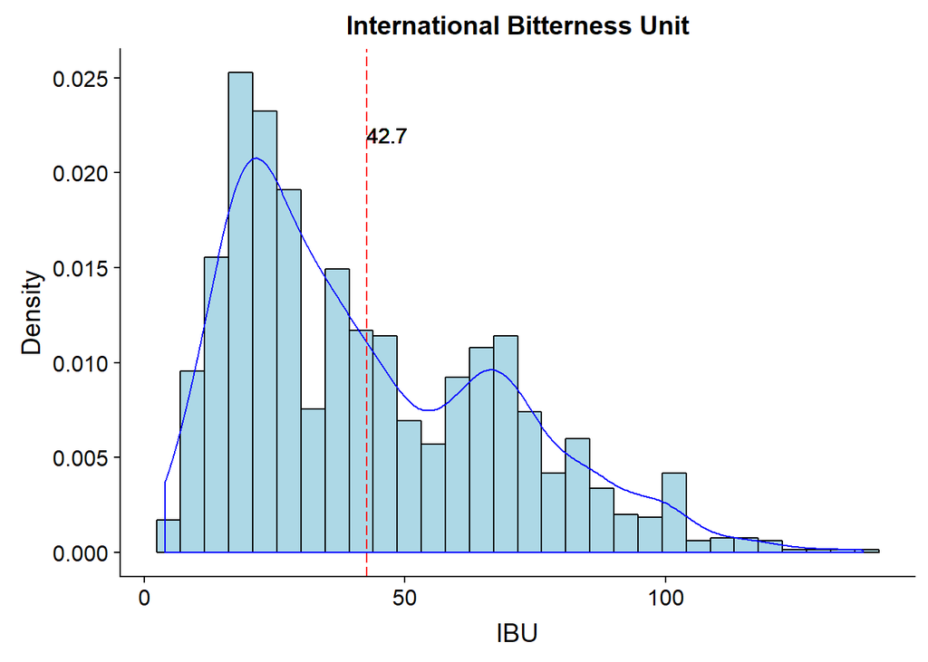

```r
ggplot(brew, aes(x=IBU)) +
 geom_histogram(aes(y=..density..), colour="black", fill="lightblue",
                position="identity")+
    geom_density(alpha=.2, color="blue")+
    geom_vline(aes(xintercept=mean(brew$IBU, na.rm = T)), color="red",
             linetype="longdash")+
    labs(title="International Bitterness Unit",x="IBU", y = "Density")+
    geom_text(data=brew, mapping=aes(x=round(mean(brew$IBU, na.rm = T),digits=2), y=0.022, label=round(mean(brew$IBU, na.rm = T),digits=1)), size=4, hjust=0)
```

##### When we looked at the correlation between alcohol content and bitterness, we see a positive linear relationship. The actual correlation between ABV and IBU is 67%. We also see slightly more clustering towards the lower alcohol content and bitterness units. The relationship between IBU an ABV is statistically significant PValue of <0.0001.

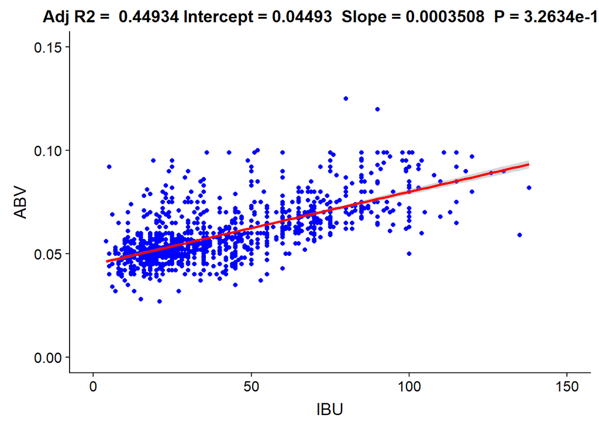

```r
ggplotRegression <- function (fit) {

require(ggplot2)

ggplot(fit$model, aes_string(x = names(fit$model)[2], y = names(fit$model)[1])) +
  geom_point(color="blue") +
xlim(0,150)+ylim(0,.150)+
  stat_smooth(method = "lm", col = "red") +
  labs(title = paste("Adj R2 = ",signif(summary(fit)$adj.r.squared, 5),
                     "Intercept =",signif(fit$coef[[1]],5 ),
                     " Slope =",signif(fit$coef[[2]], 5),
                     " P =",signif(summary(fit)$coef[2,4], 5)))
}

ggplotRegression(lm(ABV~IBU, data = brew))
```

##### There are numerous craft styles and beers produced throughout the United States. As shown by size and shade darkness, the ales tend to be the most preferred style.

```r
brew%>%
  count(Style)%>%
  arrange(n)%>%
  hchart(type = "treemap", hcaes(x = Style, value = n, color = n))
```

[interactive chart not shown]

##### Going deeper into the data, this table lists the top 10 craft beer styles and different beers produced in each style. American IPA’s are clearly the front runner with 409 different beers produced. American Pale Ales take the second spot with 234 beers.

```r
bstlexp<-as.data.frame(brew %>% group_by(Style)
  %>% summarise(Median_ABV=median(ABV, na.rm=TRUE),
 Median_IBU=median(IBU, na.rm=TRUE),
  Beers = n_distinct(Beer)))

bstlexp<-bstlexp[order(-bstlexp$Beers),]

bstlexp=bstlexp[,c(1,4,2,3)]

#kable(bstlexp)%>%
 # kable_styling(full_width = F)

#Top 10 Styles in the United States
kable(head(bstlexp,10))%>%
  kable_styling(full_width = F)
```

|  | Style | Beers | Median_ABV | Median_IBU |
| --- | --- | --- | --- | --- |
| 16 | American IPA | 409 | 0.065 | 69.0 |
| 18 | American Pale Ale (APA) | 234 | 0.055 | 44.0 |
| 5 | American Amber / Red Ale | 131 | 0.055 | 31.0 |
| 9 | American Blonde Ale | 103 | 0.050 | 20.0 |
| 12 | American Double / Imperial IPA | 100 | 0.087 | 91.0 |
| 20 | American Pale Wheat Ale | 80 | 0.048 | 20.0 |
| 10 | American Brown Ale | 68 | 0.055 | 26.0 |
| 22 | American Porter | 65 | 0.058 | 31.0 |
| 90 | Saison / Farmhouse Ale | 52 | 0.060 | 30.0 |
| 100 | Witbier | 50 | 0.050 | 15.5 |

##### These charts show by state the number of different styles and beers produced. When it comes to choice, Colorado, Indiana, California, Michigan, and Texas are the most diverse.

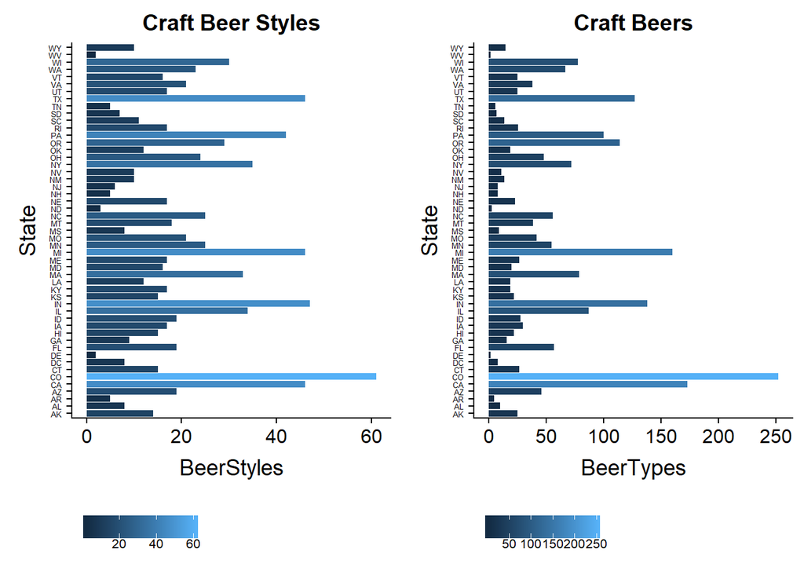

```r
bstyl<-as.data.frame(brew %>% group_by(State)%>% summarise(BeerStyles=n_distinct(Style)))
bstyl<-bstyl[order(-bstyl$BeerStyles),]

bst<-ggplot(bstyl, aes(x=State, y=BeerStyles, fill=BeerStyles)) +
  geom_bar(stat="identity") +
  ggtitle("Craft Beer Styles") +
  theme(plot.title = element_text(hjust = 0.5))+
  theme(axis.text.y = element_text(hjust=1, vjust=0.5, size=5))+
  theme(legend.position="bottom")+
  theme(legend.text = element_text(colour="black", size =8))+
  theme(legend.title = element_blank()) +
  coord_flip()

btype<-as.data.frame(brew %>% group_by(State)
        %>% summarise(BeerTypes = n_distinct(Beer)))

btp<-ggplot(btype, aes(x=State, y=BeerTypes, fill=BeerTypes)) +
  geom_bar(stat="identity") +
  ggtitle("Craft Beers") +
  theme(plot.title = element_text(hjust = 0.5))+
  theme(axis.text.y = element_text(hjust=1, vjust=0.5, size=5))+
  theme(legend.position="bottom")+
  theme(legend.text = element_text(colour="black", size =8))+
  theme(legend.title = element_blank()) +
  coord_flip()

plotb<-plot_grid(bst, btp, align="hv", nrow = 1, ncol = 2)

plotb
```

##### Craft breweries have a measurable economic impact. When it comes to craft breweries, money is generated back into the economy through wholesale distribution, individual retail sales and sales at breweries. The map below depicts each state’s economic impact (in Mil $).

```r
BrndStyl <- merge(btype, bstyl, by='State')

statesum<-merge(state, BrndStyl, by="State",all.x = TRUE)
colnames(statesum)<- c('State', 'MedianABV', 'MedianIBU', 'Breweries','BreweriesPerCapita', 'EconomicImpactMil', 'EconomicImpactRank', 'BarrelsPerYear', 'GallonsPerAdult', 'DifferentTypes', 'DifferentStyles')
statesum<-statesum[,c(1,2,3,4,10,11,5,6,7,8,9)]

reva<-statesum[order(-statesum$EconomicImpactMil),]
reva=reva[,c(1,8)]


mapdata <- get_data_from_map(download_map_data("countries/us/us-all"))

reva$State <- str_trim(reva$State,side="left")
rev <- reva %>% mutate(`hc-a2`= State);


hcmap("countries/us/us-all", data = rev, value = "EconomicImpactMil",
      joinBy = "hc-a2", name = "EconomicImpactMil",
      dataLabels = list(enabled = TRUE, format = '{point.name}'),
      borderColor = "#FAFAFA", borderWidth = 0.1,
      tooltip = list(valueDecimals = 0,valueSuffix = "Economic Impact")) %>%
    hc_mapNavigation(enabled = TRUE) %>%
    hc_title(text = "<b>Economic Impact<b>",
             margin = 20, align = "center",
             style = list(color = "#000000",
                         useHTML = TRUE))
```

[interactive chart not shown]

##### We found positive corrlation between Economic Impact Million$ vs. Breweries per State. One interesting state, Pennsylvania, has a very high Economic Impact in Million $, but not that high number of breweries in this state.

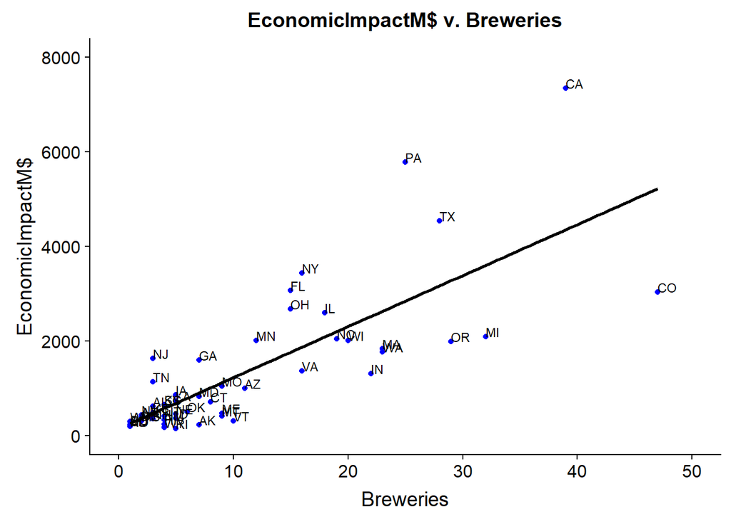

```r
#Revenue vs. breweries per state
ggplot(state, aes(Breweries, `EconomicImpactM$`)) +
geom_point(color="blue") +
xlim(0,50)+ylim(0,8000)+
  labs(x="Breweries",y="EconomicImpactM$") +
ggtitle("EconomicImpactM$ v. Breweries") +
geom_smooth(method=lm, color="black", se=FALSE) +
geom_text(aes(label=State),hjust=0, vjust=0, size=3)
```

##### There is a also a positive correlation between Breweries per Capita vs. Gallon per Adult in each state. Pennsylvania has a high value of Gallons per Adult, but the Breweries per Capita is relatively low. This means the revenue income of beer industry is high, less competitors, people tend to drink more in this state.

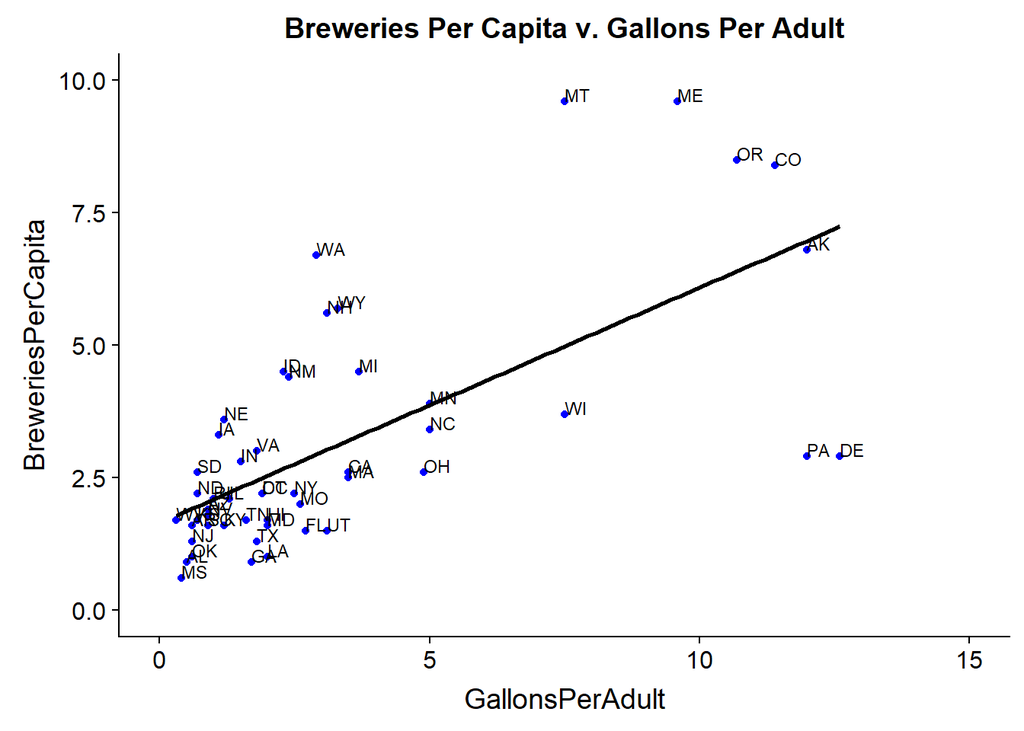

```r
#breweries per capita vs. Gallon per adult in each state
ggplot(state, aes(GallonsPerAdult, BreweriesPerCapita)) +
geom_point(color="blue") +
xlim(0,15)+ylim(0,10)+
  labs(x="GallonsPerAdult",y="BreweriesPerCapita") +
ggtitle("Breweries Per Capita v. Gallons Per Adult") +
geom_smooth(method=lm, color="black", se=FALSE)+
  geom_text(aes(label=State),hjust=0, vjust=0, size=3)
```

##### Summary statistics for Economic Impact (Mil$) and Annual Barrel Production

```r
Economic_Impact_In_Millions<-summary(state$`EconomicImpactM$`)

Barrels_Produced_Annually<-summary(state$BarrelsPerYear)

eco<-rbind(Economic_Impact_In_Millions)
kable(eco)%>%
  kable_styling(full_width = F)
```

|  | Min. | 1st Qu. | Median | Mean | 3rd Qu. | Max. |
| --- | --- | --- | --- | --- | --- | --- |
| Economic_Impact_In_Millions | 152 | 359.5 | 718 | 1328.333 | 1913 | 7345 |

```r
prd<-rbind(Barrels_Produced_Annually)
kable(prd)%>%
  kable_styling(full_width = F)
```

|  | Min. | 1st Qu. | Median | Mean | 3rd Qu. | Max. |
| --- | --- | --- | --- | --- | --- | --- |
| Barrels_Produced_Annually | 12848 | 67091 | 206529 | 495699.6 | 547788.5 | 3724010 |

##### California and Pennsylvania top the nation’s list in terms of craft beer’s impact on state economies. California comes in at No. 1 with an economic impact of $7.4B and Pennsylvania at No. 2 with $5.8B. Texas is also a significant player at with an economic impact of $4.5B

```r
kable(head(reva,10))%>%
  kable_styling(full_width = F)
```

|  | State | EconomicImpactMil |
| --- | --- | --- |
| 5 | CA | 7345 |
| 39 | PA | 5788 |
| 44 | TX | 4540 |
| 35 | NY | 3439 |
| 10 | FL | 3074 |
| 6 | CO | 3037 |
| 36 | OH | 2675 |
| 15 | IL | 2602 |
| 23 | MI | 2094 |
| 28 | NC | 2042 |

Top 10 States - Barrel Production

```r
bars<-statesum[order(-statesum$BarrelsPerYear),]
bars=bars[,c(1,10)]

kable(head(bars,10))%>%
  kable_styling(full_width = F)
```

|  | State | BarrelsPerYear |
| --- | --- | --- |
| 39 | PA | 3724010 |
| 5 | CA | 3285525 |
| 6 | CO | 1523204 |
| 10 | FL | 1408032 |
| 36 | OH | 1355279 |
| 35 | NY | 1211494 |
| 28 | NC | 1211393 |
| 44 | TX | 1156536 |
| 38 | OR | 1078391 |
| 49 | WI | 1029916 |

### Recommendations

##### One approach is re-entry into the craft beer market; building a brewery to craft beer specifics. Based on our analysis, the market is saturated with American IPAs creating an extremely competitive landscape. We recommend initial product development in the American Pale Ale category. Data suggests that this style is growing in popularity since it continues to evolve. Brewers are reinventing the classic pale ale by experimenting with local ingredients to craft flavor profiles that push boundaries. In addition, the IBU and ABV characteristics of this style fall within our identified consumer preference area.

##### In terms of location, our analysis concluded that the western region is highly developed which creates a significant barrier to entry. The Midwest region is an ideal market. The key states in the region, Illinois, Michicgan, Minnesota, Ohio and Wisconsin have economic impact ranks in the top 15 and there has been a significant shift of consumer preference to craft beers. The southern region is starting to make inroads into the market, while the Northeast isn’t quite there yet.

##### Our recommendation is to build a craft brewery in Illinois. There is proximity to the Pacific Northwest for fresh hops, which has the flavor profile consumers prefer. As we have existing breweries in Ohio and Missouri, we will be able to realize economies of scale with many of the ingredients/equipment. We will also be able to utilize Missouri’s distribution network.

##### The other option is to acquire an existing brewery in the Western region and expanding the product line into the other regions of the US.

##### One interesting brewery we discovered is the Anderson Valley Brewing Company and Tap Room in California. Founded in 1987 they have continued to grow their brand from a 10 barrel brewhouse to a 100 barrel brewhouse. They have a strong portfolio of ales and lagers and they also have an exclusive partnership with Wild Turkey Bourbon which has enabled them to create a secondary market niche. They have also created a consumer experience which sets them apart by building a golf course on the grounds.

##### We can do more analysis to specific state, like Pennsylvania, it has a high economic revenue of beer industry, less competitors,but people tend to drink more in this state. This can be a good business opportunity.

### APPENDIX

##### Other interesting graphs and fulll data for some of the abbreviated data tables in the report

Craft Beer Styles in order of popularity

```r
kable(bstlexp)%>%
kable_styling(full_width = F)
```

|  | Style | Beers | Median_ABV | Median_IBU |
| --- | --- | --- | --- | --- |
| 16 | American IPA | 409 | 0.0650 | 69.0 |
| 18 | American Pale Ale (APA) | 234 | 0.0550 | 44.0 |
| 5 | American Amber / Red Ale | 131 | 0.0550 | 31.0 |
| 9 | American Blonde Ale | 103 | 0.0500 | 20.0 |
| 12 | American Double / Imperial IPA | 100 | 0.0870 | 91.0 |
| 20 | American Pale Wheat Ale | 80 | 0.0480 | 20.0 |
| 10 | American Brown Ale | 68 | 0.0550 | 26.0 |
| 22 | American Porter | 65 | 0.0580 | 31.0 |
| 90 | Saison / Farmhouse Ale | 52 | 0.0600 | 30.0 |
| 100 | Witbier | 50 | 0.0500 | 15.5 |
| 61 | Fruit / Vegetable Beer | 46 | 0.0510 | 15.5 |
| 69 | K?lsch | 41 | 0.0500 | 22.0 |
| 23 | American Stout | 39 | 0.0610 | 40.0 |
| 65 | Hefeweizen | 39 | 0.0500 | 15.0 |
| 19 | American Pale Lager | 36 | 0.0500 | 18.5 |
| 39 | Cider | 36 | 0.0650 | NA |
| 62 | German Pilsener | 36 | 0.0500 | 35.0 |
| 8 | American Black Ale | 33 | 0.0680 | 73.0 |
| 40 | Cream Ale | 28 | 0.0545 | 20.0 |
| 41 | Czech Pilsener | 27 | 0.0500 | 33.0 |
| 6 | American Amber / Red Lager | 26 | 0.0490 | 23.0 |
| 21 | American Pilsner | 25 | 0.0500 | 21.5 |
| 30 | Belgian Pale Ale | 24 | 0.0600 | 21.0 |
| 74 | M?rzen / Oktoberfest | 24 | 0.0570 | 23.0 |
| 83 | Pumpkin Ale | 23 | 0.0550 | 20.0 |
| 79 | Munich Helles Lager | 19 | 0.0475 | 18.0 |
| 29 | Belgian IPA | 18 | 0.0700 | 61.0 |
| 48 | English Brown Ale | 18 | 0.0535 | 20.5 |
| 57 | Extra Special / Strong Bitter (ESB) | 18 | 0.0560 | 41.0 |
| 89 | Rye Beer | 18 | 0.0630 | 57.0 |

[output cut: 70 more lines]

Revenue by State in M$

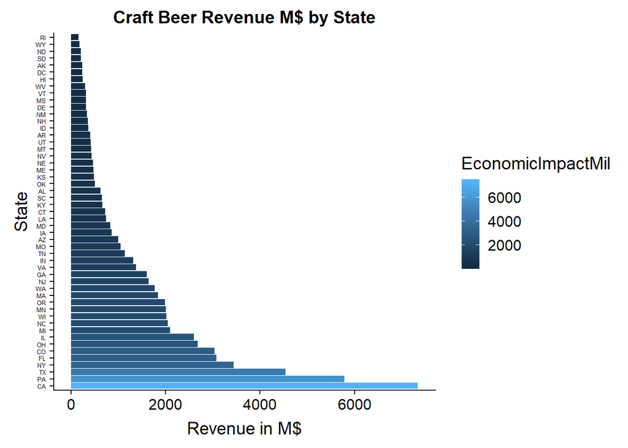

```r
ggplot(reva, aes(x=reorder(State, -EconomicImpactMil), y=EconomicImpactMil, fill=EconomicImpactMil)) +
  geom_bar(stat="identity") +
  labs(x="State",y="Revenue in M$") +
  ggtitle("Craft Beer Revenue M$ by State") +
  theme(plot.title = element_text(hjust = 0.5))+ #forces centering
  theme(axis.text.y = element_text(hjust=1, vjust=0.5, size=5))+
  coord_flip()
```

```r
kable(reva)%>%
  kable_styling(full_width = F)
```

|  | State | EconomicImpactMil |
| --- | --- | --- |
| 5 | CA | 7345 |
| 39 | PA | 5788 |
| 44 | TX | 4540 |
| 35 | NY | 3439 |
| 10 | FL | 3074 |
| 6 | CO | 3037 |
| 36 | OH | 2675 |
| 15 | IL | 2602 |
| 23 | MI | 2094 |
| 28 | NC | 2042 |
| 49 | WI | 2015 |
| 24 | MN | 2007 |
| 38 | OR | 1988 |
| 20 | MA | 1838 |
| 48 | WA | 1770 |
| 32 | NJ | 1636 |
| 11 | GA | 1596 |
| 46 | VA | 1373 |
| 16 | IN | 1309 |
| 43 | TN | 1135 |
| 25 | MO | 1047 |
| 4 | AZ | 1000 |
| 13 | IA | 861 |
| 21 | MD | 826 |
| 19 | LA | 740 |
| 7 | CT | 718 |
| 18 | KY | 657 |
| 41 | SC | 650 |
| 2 | AL | 616 |
| 37 | OK | 502 |
| 17 | KS | 480 |
| 22 | ME | 476 |
| 30 | NE | 465 |
| 34 | NV | 434 |
| 27 | MT | 417 |
| 45 | UT | 415 |
| 3 | AR | 406 |
| 14 | ID | 366 |
| 31 | NH | 353 |
| 33 | NM | 333 |
| 9 | DE | 318 |
| 26 | MS | 310 |
| 47 | VT | 309 |
| 50 | WV | 293 |
| 12 | HI | 245 |
| 8 | DC | 235 |
| 1 | AK | 232 |
| 42 | SD | 209 |
| 29 | ND | 200 |
| 51 | WY | 177 |
| 40 | RI | 152 |

Beer and Brand Style by State

```r
kable(BrndStyl)%>%
  kable_styling(full_width = F)
```

| State | BeerTypes | BeerStyles |
| --- | --- | --- |
| AK | 25 | 14 |
| AL | 10 | 8 |
| AR | 5 | 5 |
| AZ | 46 | 19 |
| CA | 173 | 46 |
| CO | 252 | 61 |
| CT | 27 | 15 |
| DC | 8 | 8 |
| DE | 2 | 2 |
| FL | 57 | 19 |
| GA | 16 | 9 |
| HI | 22 | 15 |
| IA | 30 | 17 |
| ID | 28 | 19 |
| IL | 87 | 34 |
| IN | 138 | 47 |
| KS | 22 | 15 |
| KY | 19 | 17 |
| LA | 19 | 12 |
| MA | 79 | 33 |
| MD | 20 | 16 |
| ME | 27 | 17 |
| MI | 160 | 46 |
| MN | 55 | 25 |
| MO | 42 | 21 |
| MS | 9 | 8 |
| MT | 39 | 18 |
| NC | 56 | 25 |
| ND | 3 | 3 |
| NE | 23 | 17 |
| NH | 8 | 5 |
| NJ | 8 | 6 |
| NM | 14 | 10 |
| NV | 11 | 10 |
| NY | 72 | 35 |
| OH | 48 | 24 |
| OK | 19 | 12 |
| OR | 114 | 29 |
| PA | 100 | 42 |
| RI | 26 | 17 |
| SC | 14 | 11 |
| SD | 7 | 7 |
| TN | 6 | 5 |
| TX | 127 | 46 |
| UT | 25 | 17 |
| VA | 38 | 21 |
| VT | 25 | 16 |
| WA | 67 | 23 |
| WI | 78 | 30 |
| WV | 2 | 2 |
| WY | 15 | 10 |

Gallons Per Adult 21+ by State

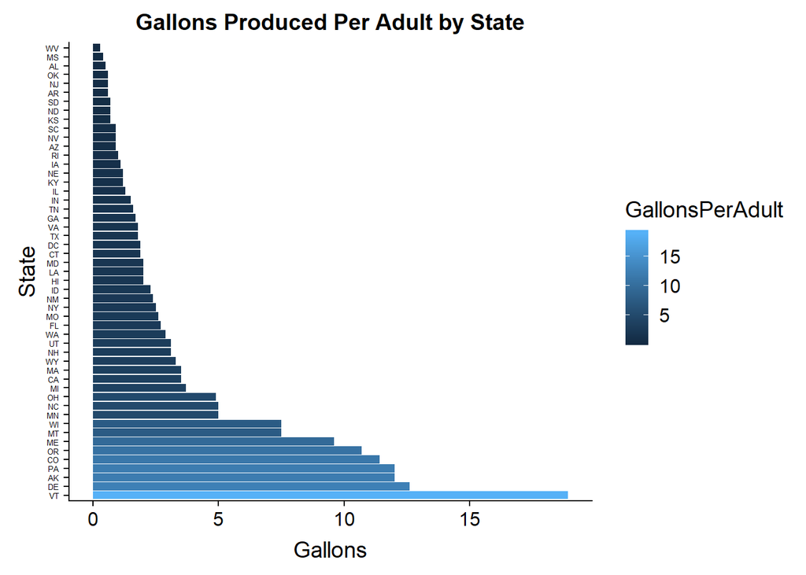

```r
cons<-statesum[order(-statesum$GallonsPerAdult),]
cons=cons[,c(1,11)]


ggplot(cons, aes(x=reorder(State, -GallonsPerAdult), y=GallonsPerAdult, fill=GallonsPerAdult)) +
  geom_bar(stat="identity") +
  labs(x="State",y="Gallons") +
  ggtitle("Gallons Produced Per Adult by State") +
  theme(plot.title = element_text(hjust = 0.5))+
  theme(axis.text.y = element_text(hjust=1, vjust=0.5, size=5))+
  coord_flip()
```

```r
kable(cons)%>%
  kable_styling(full_width = F)
```

|  | State | GallonsPerAdult |
| --- | --- | --- |
| 47 | VT | 18.9 |
| 9 | DE | 12.6 |
| 1 | AK | 12.0 |
| 39 | PA | 12.0 |
| 6 | CO | 11.4 |
| 38 | OR | 10.7 |
| 22 | ME | 9.6 |
| 27 | MT | 7.5 |
| 49 | WI | 7.5 |
| 24 | MN | 5.0 |
| 28 | NC | 5.0 |
| 36 | OH | 4.9 |
| 23 | MI | 3.7 |
| 5 | CA | 3.5 |
| 20 | MA | 3.5 |
| 51 | WY | 3.3 |
| 31 | NH | 3.1 |
| 45 | UT | 3.1 |
| 48 | WA | 2.9 |
| 10 | FL | 2.7 |
| 25 | MO | 2.6 |
| 35 | NY | 2.5 |
| 33 | NM | 2.4 |
| 14 | ID | 2.3 |
| 12 | HI | 2.0 |
| 19 | LA | 2.0 |
| 21 | MD | 2.0 |
| 7 | CT | 1.9 |
| 8 | DC | 1.9 |
| 44 | TX | 1.8 |
| 46 | VA | 1.8 |
| 11 | GA | 1.7 |
| 43 | TN | 1.6 |
| 16 | IN | 1.5 |
| 15 | IL | 1.3 |
| 18 | KY | 1.2 |
| 30 | NE | 1.2 |
| 13 | IA | 1.1 |
| 40 | RI | 1.0 |
| 4 | AZ | 0.9 |
| 34 | NV | 0.9 |
| 41 | SC | 0.9 |
| 17 | KS | 0.7 |
| 29 | ND | 0.7 |
| 42 | SD | 0.7 |
| 3 | AR | 0.6 |
| 32 | NJ | 0.6 |
| 37 | OK | 0.6 |
| 2 | AL | 0.5 |
| 26 | MS | 0.4 |
| 50 | WV | 0.3 |

Revenue vs. breweries per state

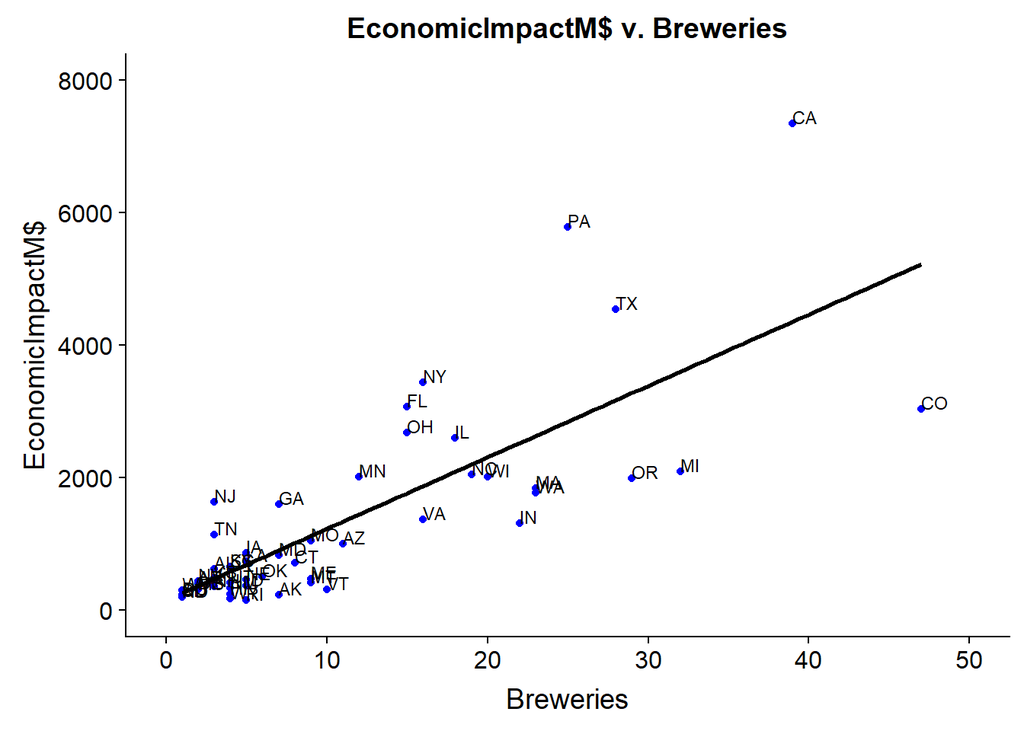

```r
ggplot(state, aes(Breweries, `EconomicImpactM$`)) +
geom_point(color="blue") +
xlim(0,50)+ylim(0,8000)+
  labs(x="Breweries",y="EconomicImpactM$") +
ggtitle("EconomicImpactM$ v. Breweries") +
geom_smooth(method=lm, color="black", se=FALSE) +
geom_text(aes(label=State),hjust=0, vjust=0, size=3)
```

breweries per capita vs. Gallon per adult in each state

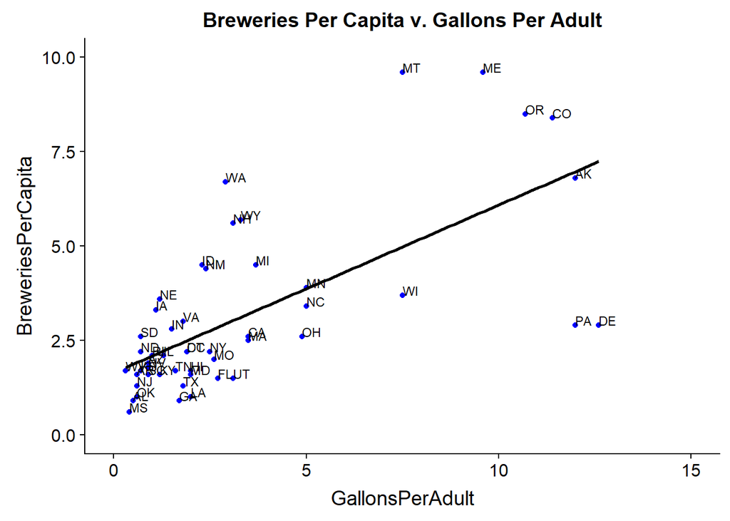

```r
ggplot(state, aes(GallonsPerAdult, BreweriesPerCapita)) +
geom_point(color="blue") +
xlim(0,15)+ylim(0,10)+
  labs(x="GallonsPerAdult",y="BreweriesPerCapita") +
ggtitle("Breweries Per Capita v. Gallons Per Adult") +
geom_smooth(method=lm, color="black", se=FALSE)+
  geom_text(aes(label=State),hjust=0, vjust=0, size=3)
```

##### Sources

*https://www.brewersassociation.org/*

*https://www.highcharts.com/docs/maps/map-collection*